# Data 624 HW3

V Patel

2020-09-20

```r
if (!require("fpp2")) install.packages("fpp2")
if (!require("seasonal")) install.packages("seasonal")
```

### 6.2 The `plastics` data set consists of the monthly sales (in thousands) of product A for a plastics manufacturer for five years.

#### A. Plot the time series of sales of product A. Can you identify seasonal fluctuations and/or a trend-cycle?

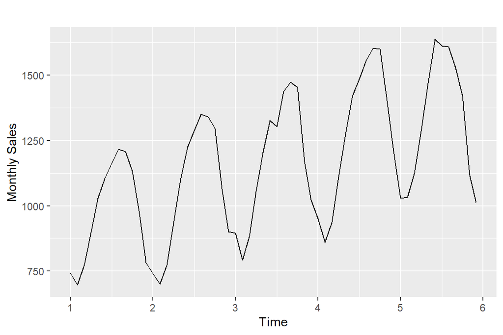

```r
autoplot(plastics) + ylab("Monthly Sales")
```

**There is a increasing trend in the timeseries. All sales are at peak in summer**

#### B. Use a classical multiplicative decomposition to calculate the trend-cycle and seasonal indices.

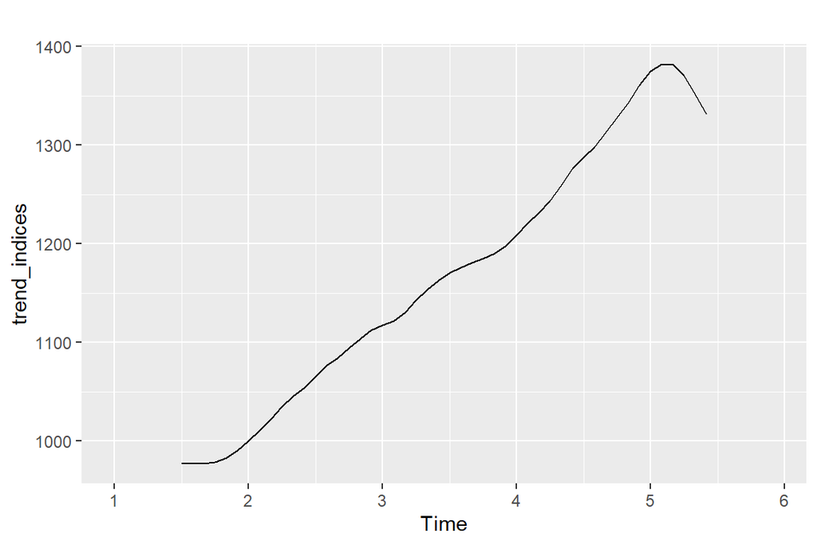

```r
fit <- decompose(plastics, type="multiplicative")

trend_indices <- fit$trend
seasonal_indices <- fit$seasonal

autoplot(trend_indices)
```

**The results in of the multiplicative decomposition show that there is an increasing trend till 5 years. After that we can see decreasing it is decresing.**

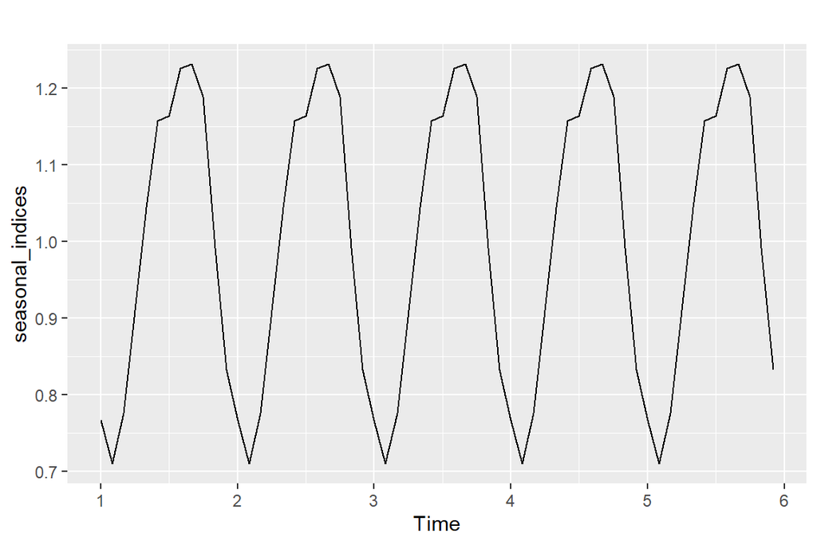

```r
autoplot(seasonal_indices)
```

**seasonal_indices is identical in thoughout all years**

#### C. Do the results support the graphical interpretation from part a?

**Yes, Results does support the graphical interpretation. summer months does have sales higher than other seasonal**

#### D. Compute and plot the seasonally adjusted data.

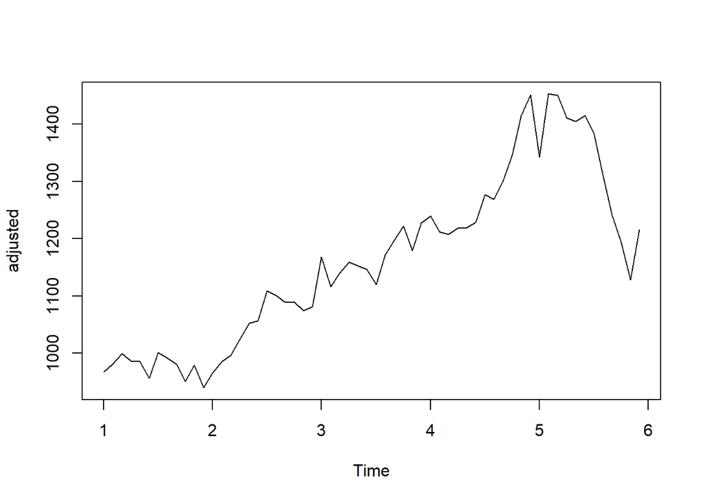

```r
adjusted <- seasadj(fit)
plot(adjusted)
```

#### E. Change one observation to be an outlier (e.g., add 500 to one observation), and recompute the seasonally adjusted data. What is the effect of the outlier?

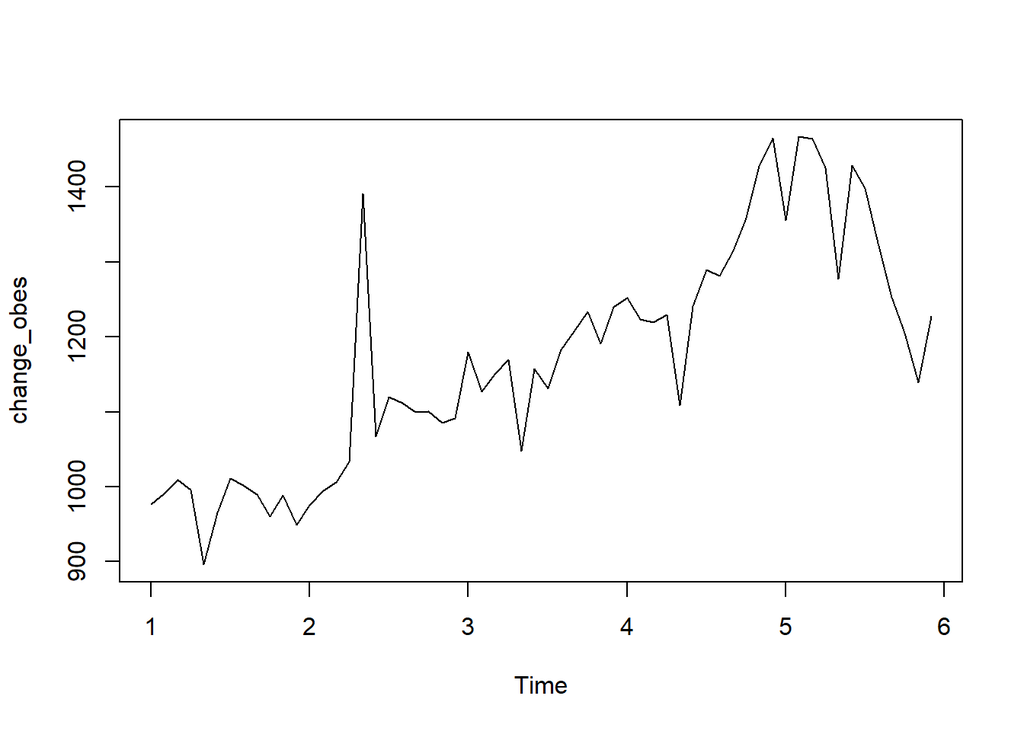

```r
obs_plast <- plastics
obs_plast[17] = obs_plast[17] + 500

fit2 <- decompose(obs_plast, type="multiplicative")

change_obes <- seasadj(fit2)
plot(change_obes)
```

**There is sudden spike in plot**

#### F. Does it make any difference if the outlier is near the end rather than in the middle of the time series?

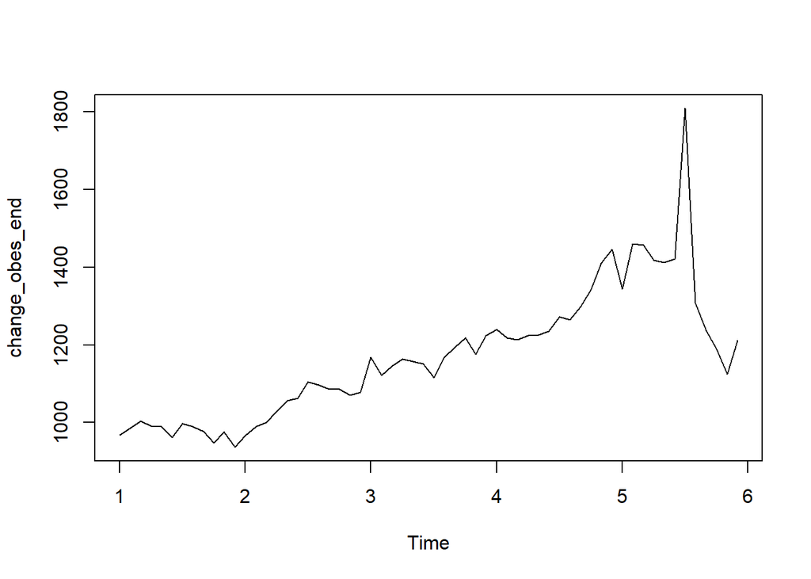

```r
obs_plast1 <- plastics
obs_plast1[55] = obs_plast[55] + 500

fit3 <- decompose(obs_plast1, type="multiplicative")

change_obes_end <- seasadj(fit3)
plot(change_obes_end)
```

### 6.3 Recall your retail time series data (from Exercise 3 in Section 2.10). Decompose the series using X11. Does it reveal any outliers, or unusual features that you had not noticed previously?

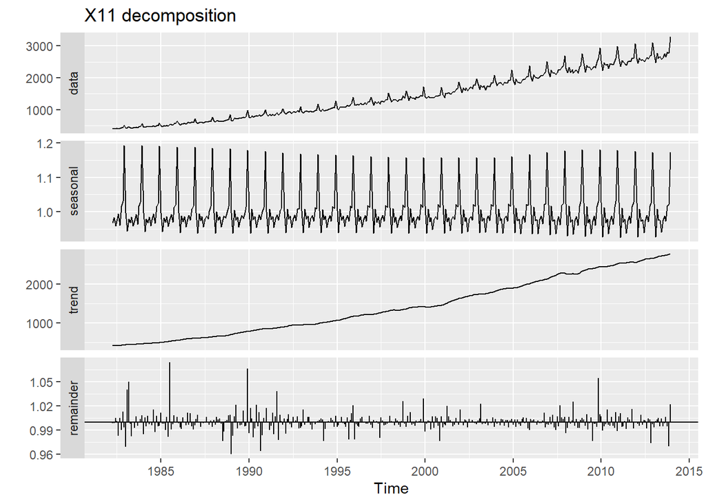

```r
library(readxl)
library(seasonal)

retaildata <- readxl::read_excel("C:/Users/patel/Documents/Data_624/retail.xlsx", skip=1)

myts <- ts(retaildata[,"A3349398A"], frequency=12, start=c(1982,4))
myts %>% seas(x11="") -> myts_x11
autoplot(myts_x11) +
  ggtitle("X11 decomposition")
```

**The X11 decomposition method reveals a smooth upward trend. The remainder plot describes that after 1992 trend and seasonality appear consistent. The unusual features that I had not noticed previously was there is sudden spike at 1986 in remainder plot despite there is consistancy in tread before and after that.**